# UK inflation up to August 2022

1st October 2022

*All data and quoted text in this document is taken from the latest [consumer price inflation bulletin](https://www.ons.gov.uk/economy/inflationandpriceindices/bulletins/consumerpriceinflation/latest) released by the Office for National Statistics (ONS).*

# 1 Measuring inflation

> Consumer price inflation is the rate at which the prices of the goods and services bought by households rise or fall; it is estimated by using consumer price indices. One way to understand a price index is to think of a very large shopping basket containing all the goods and services bought by households. The price index estimates changes to the total cost of this basket. Households spend more on some goods and services than others. For example, a 10% increase in the price of petrol will have a much bigger impact on the basket than a similar rise in the price of tea. For this reason, the components of price indices are weighted using the amount we all spend on these items as consumers, to ensure that it reflects the relative importance of the various items in the average shopping basket.

The preferred price index of the ONS is the Consumer Prices Index including owner occupiers’ housing costs (CPIH):

> CPIH is the most comprehensive measure of inflation. It extends the Consumer Prices Index (CPI) to include a measure of the costs associated with owning, maintaining and living in one’s own home, known as owner occupiers’ housing costs (OOH), along with Council Tax. Both are significant expenses for many households and are not included in the CPI.

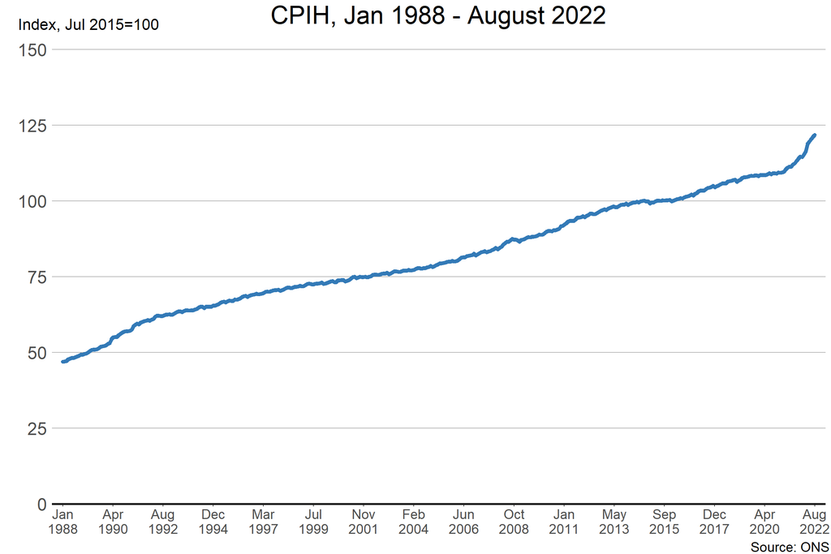

# 2 The rate of inflation

> The most common approach to measuring inflation is the 12-month or annual inflation rate, which compares prices for the latest month with the same month a year ago. In any given month, the 12-month rate is determined by the balance between upward and downward price movements of the range of goods and services included in the index.

For example, the CPIH in May 2021 was 111.0 and in May 2022 was 119.7 – an increase of 7.9%.

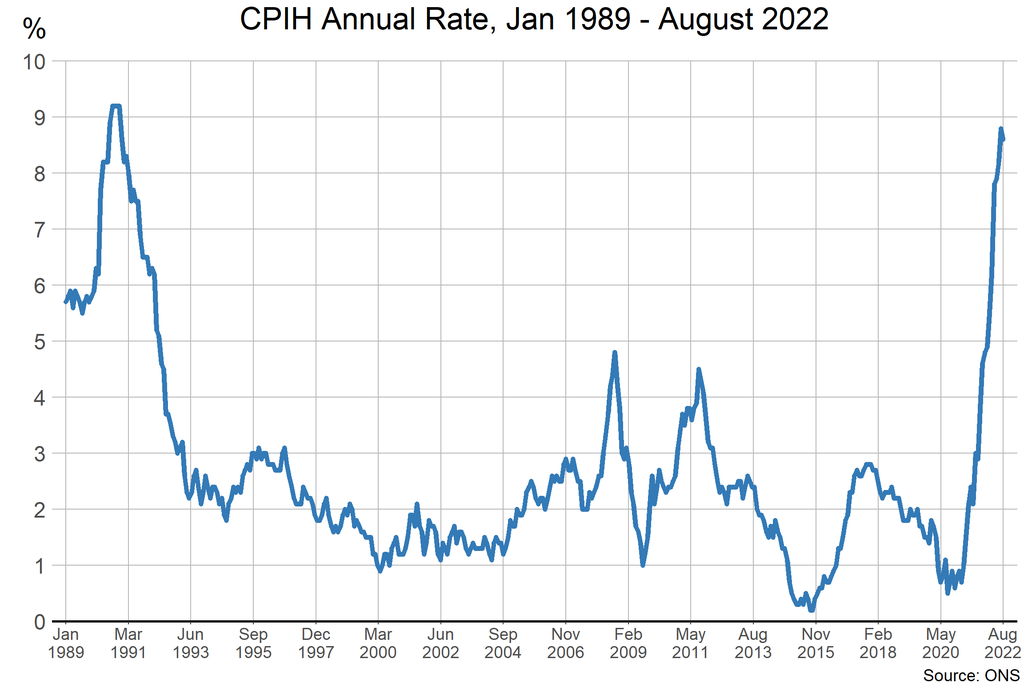

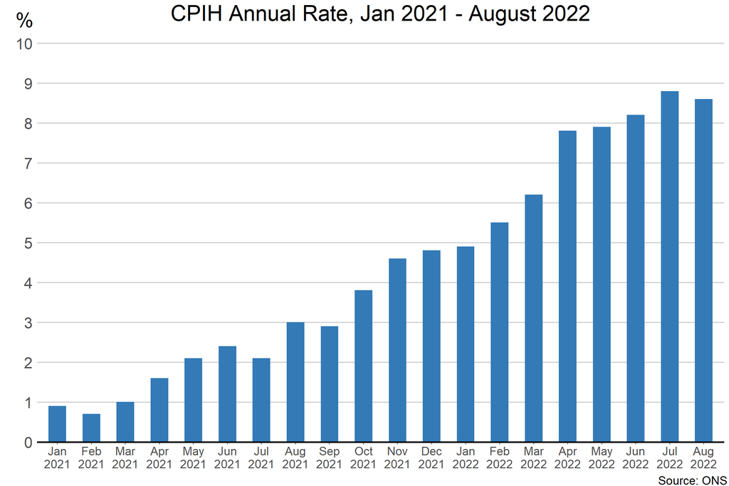

# 3 The drivers of inflation

| Category | Annual Rate |
| --- | --- |
| Gas | 95.7% |
| Electricity | 54.0% |
| Diesel | 36.2% |
| Petrol | 30.2% |
| Oils and fats | 29.4% |
| Flours and other cereals | 28.2% |
| Pasta products and couscous | 26.3% |
| Whole milk | 17.6% |
| Transport | 16.3% |
| Poultry | 13.1% |
| Housing and household services | 12.4% |
| Food and non-alcoholic beverages | 9.2% |